# Lending Club Data Exploration and Visualization

Myriam Munezero

29 May 2018

## Introduction

Lending clubs are peer-to-peer lending companies. Lending clubs operates an online lending platform that enables borrowers to obtain a loan, and investors to purchase notes backed by payments made on loans (Source: Wikipedia).

We have three data sets that pertain to the borrower, loan classification, and the payments information. Our objective is to work with the data, explore it and perhaps gain some insights into it.

### We will go through

- Reading in the data
- Data cleaning and preprocessing
- Feature transformation
- Exploration and visualization

## Load needed libraries

```r
library(ggplot2)
library(stringr)
library(dplyr)
library(lubridate)
library(reshape2)
library(corrplot)
```

## Import the data

```r
outDir<-"data"
fileurl="https://storage.googleapis.com/acn-data-storage/recruitment-task/Loan%20Data.zip"

if (!file.exists(outDir)){
  download.file(fileurl, "Loandata.zip", method = "libcurl")
}

zipF<-"Loandata.zip"
unzip(zipF, exdir = outDir)
```

## Read in the data

```r
borrower_df<-read.csv("data/Borrower Information.csv", na.strings = "NA")
loan_class_df<- read.csv("data/Loan Classification Information.csv", na.strings = "NA")
loan_payment_info<-load(file = "data/Loan Payment Information.Rda")
payments_df<-Payment.df
```

## View how the data looks like

```r
head(borrower_df)
```

```
##   X member_id                emp_title emp_length home_ownership zip_code
## 1 1   1296599                           10+ years           RENT    860xx
## 2 2   1314167                    Ryder   < 1 year           RENT    309xx
## 3 3   1313524                           10+ years           RENT    606xx
## 4 4   1277178      AIR RESOURCES BOARD  10+ years           RENT    917xx
## 5 5   1311748 University Medical Group     1 year           RENT    972xx
## 6 6   1311441     Veolia Transportaton    3 years           RENT    852xx
##   addr_state annual_inc annual_inc_joint open_acc pub_rec total_acc
## 1         AZ      24000               NA        3       0         9
## 2         GA      30000               NA        3       0         4
## 3         IL      12252               NA        2       0        10
## 4         CA      49200               NA       10       0        37
## 5         OR      80000               NA       15       0        38
## 6         AZ      36000               NA        9       0        12
##   delinq_2yrs earliest_cr_line
## 1           0         Jan-1985
## 2           0         Apr-1999
## 3           0         Nov-2001
## 4           0         Feb-1996
## 5           0         Jan-1996
## 6           0         Nov-2004
```

```r
head(loan_class_df)
```

```
##   X      id member_id       term grade sub_grade loan_status pymnt_plan
## 1 1 1077501   1296599  36 months     B        B2  Fully Paid          n
## 2 2 1077430   1314167  60 months     C        C4 Charged Off          n
## 3 3 1077175   1313524  36 months     C        C5  Fully Paid          n
## 4 4 1076863   1277178  36 months     C        C1  Fully Paid          n
## 5 5 1075358   1311748  60 months     B        B5     Current          n
## 6 6 1075269   1311441  36 months     A        A4  Fully Paid          n
##          purpose application_type  issue_d
## 1    credit_card       INDIVIDUAL Dec-2011
## 2            car       INDIVIDUAL Dec-2011
## 3 small_business       INDIVIDUAL Dec-2011
## 4          other       INDIVIDUAL Dec-2011
## 5          other       INDIVIDUAL Dec-2011
## 6        wedding       INDIVIDUAL Dec-2011
##                                                                                                                                                                                                                                                                                                          …
```

[output cut: 20 more lines]

```r
head(payments_df)
```

```
##        id   dti inq_last_6mths mths_since_last_delinq
## 1 1077501 27.65              1                     NA
## 2 1077430  1.00              5                     NA
## 3 1077175  8.72              2                     NA
## 4 1076863 20.00              1                     35
## 5 1075358 17.94              0                     38
## 6 1075269 11.20              3                     NA
##   mths_since_last_record revol_bal revol_util out_prncp out_prncp_inv
## 1                     NA     13648       83.7       0.0           0.0
## 2                     NA      1687        9.4       0.0           0.0
## 3                     NA      2956       98.5       0.0           0.0
## 4                     NA      5598       21.0       0.0           0.0
## 5                     NA     27783       53.9     766.9         766.9
## 6                     NA      7963       28.3       0.0           0.0
##   total_pymnt total_pymnt_inv total_rec_prncp total_rec_int
```

[output cut: 55 more lines]

## Data cleaning and preprocessing

Let’s first merge the datasets

```r
loan_df<-merge(loan_class_df, payments_df, by="id")
full_df<-merge(borrower_df, loan_df, by="member_id")
```

Check the missing colums

```r
sapply(full_df, function(x) sum(length(which(is.na(x)))))
```

```
##                   member_id                         X.x
##                           0                           0
##                   emp_title                  emp_length
##                           0                           0
##              home_ownership                    zip_code
##                           0                           0
##                  addr_state                  annual_inc
##                           0                           4
##            annual_inc_joint                    open_acc
##                      886868                          29
##                     pub_rec                   total_acc
##                          29                          29
##                 delinq_2yrs            earliest_cr_line
##                          29                           0
##                          id                         X.y
##                           0                           0
##                        term                       grade
##                           0                           0
##                   sub_grade                 loan_status
##                           0                           0
##                  pymnt_plan                     purpose
##                           0                           0
##            application_type                     issue_d
##                           0                           0
##                        desc                       title
##                           0                           0
##                   loan_amnt                    int_rate
##                           0                           0
##                 funded_amnt             funded_amnt_inv
##                           0                           0
##                 installment                         dti
##                           0                           0
##              inq_last_6mths      mths_since_last_delinq
##                          29                      454312
##      mths_since_last_record                   revol_bal
##                      750326                           0
##                  revol_util                   out_prncp
##                         502                           0
##               out_prncp_inv                 total_pymnt
##                           0                           0
```

[output cut: 15 more lines]

```
##                       70276                       70276
##                 open_acc_6m                  open_il_6m
##                      866007                      866007
##                 open_il_12m                 open_il_24m
##                      866007                      866007
##          mths_since_rcnt_il                total_bal_il
##                      866569                      866007
##                     il_util                 open_rv_12m
##                      868762                      866007
##                 open_rv_24m                  max_bal_bc
##                      866007                      866007
##                    all_util                      inq_fi
##                      866007                      866007
##                 total_cu_tl                inq_last_12m
##                      866007                      866007
```

Remove columns where majority of columns are empty

```r
full_df<-full_df[, -which(colMeans(is.na(full_df)) > 0.5)]
```

Remove unneeded colums

```r
to_remove = c('X.x', 'emp_title', 'X.y', 'desc', 'title', 'zip_code', 'earliest_cr_line', 'sub_grade', 'last_pymnt_d', 'next_pymnt_d', 'last_credit_pull_d', 'recoveries', 'collection_recovery_fee', 'pymnt_plan', 'application_type')
full_df<-full_df[, !(names(full_df) %in% to_remove)]
```

## Feature transformation

First transform the ‘term’ column

```r
full_df$term<-str_replace_all(full_df$term, " months", "")
full_df$term<-as.numeric(full_df$term)
```

Transform the ‘emp_length’ column

```r
full_df$emp_length<-str_replace_all(full_df$emp_length, "n/a", "0")
full_df$emp_length<-str_replace_all(full_df$emp_length, "\\+ years", "")
full_df$emp_length<-str_replace_all(full_df$emp_length, " years", "")
full_df$emp_length<-str_replace_all(full_df$emp_length, "< 1 year", "0")
full_df$emp_length<-str_replace_all(full_df$emp_length, " year", "")
full_df$emp_length<-as.numeric(full_df$emp_length)
```

Transform the ‘grade’ column

```r
full_df$grade<-str_replace_all(full_df$grade, "A", "1")
full_df$grade<-str_replace_all(full_df$grade, "B", "2")
full_df$grade<-str_replace_all(full_df$grade, "C", "3")
full_df$grade<-str_replace_all(full_df$grade, "D", "4")
full_df$grade<-str_replace_all(full_df$grade, "E", "5")
full_df$grade<-str_replace_all(full_df$grade, "F", "6")
full_df$grade<-str_replace_all(full_df$grade, "G", "7")
full_df$grade<-as.numeric(full_df$grade)
```

Transform loan_status

```r
full_df$loan_status[full_df$loan_status=="Does not meet the credit policy. Status:Fully Paid"]<-"Fully Paid"
full_df$loan_status[full_df$loan_status=="Does not meet the credit policy. Status:Charged Off"]<-"Charged Off"
full_df$loan_status<-factor(full_df$loan_status)
```

## Impute missing values

Check the pattern of missing values

```r
library(mice)
md.pattern(full_df)
```

```
##        member_id emp_length home_ownership addr_state id term grade
## 816722         1          1              1          1  1    1     1
##    381         1          1              1          1  1    1     1
##  70042         1          1              1          1  1    1     1
##     89         1          1              1          1  1    1     1
##    113         1          1              1          1  1    1     1
##      3         1          1              1          1  1    1     1
##     25         1          1              1          1  1    1     1
##      4         1          1              1          1  1    1     1
##                0          0              0          0  0    0     0
##        loan_status purpose issue_d loan_amnt int_rate funded_amnt
## 816722           1       1       1         1        1           1
##    381           1       1       1         1        1           1
##  70042           1       1       1         1        1           1
##     89           1       1       1         1        1           1
```

[output cut: 65 more lines]

Another way to visualize missing values

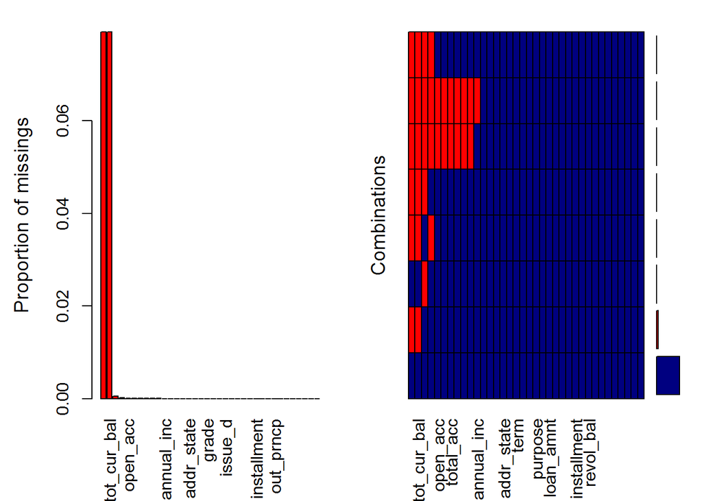

```
##
##  Variables sorted by number of missings:
##                    Variable          Count
##                tot_coll_amt 0.079195022645
##                 tot_cur_bal 0.079195022645
##                  revol_util 0.000565710931
##  collections_12_mths_ex_med 0.000163402560
##                    open_acc 0.000032680512
##                     pub_rec 0.000032680512
##                   total_acc 0.000032680512
##                 delinq_2yrs 0.000032680512
##              inq_last_6mths 0.000032680512
##              acc_now_delinq 0.000032680512
##                  annual_inc 0.000004507657
##                   member_id 0.000000000000
##                  emp_length 0.000000000000
##              home_ownership 0.000000000000
##                  addr_state 0.000000000000
##                          id 0.000000000000
##                        term 0.000000000000
##                       grade 0.000000000000
##                 loan_status 0.000000000000
##                     purpose 0.000000000000
##                     issue_d 0.000000000000
##                   loan_amnt 0.000000000000
##                    int_rate 0.000000000000
##                 funded_amnt 0.000000000000
##             funded_amnt_inv 0.000000000000
##                 installment 0.000000000000
##                         dti 0.000000000000
##                   revol_bal 0.000000000000
##                   out_prncp 0.000000000000
##               out_prncp_inv 0.000000000000
##                 total_pymnt 0.000000000000
##             total_pymnt_inv 0.000000000000
##             total_rec_prncp 0.000000000000
##               total_rec_int 0.000000000000
##          total_rec_late_fee 0.000000000000
##             last_pymnt_amnt 0.000000000000
```

```r
library(VIM)
aggr(full_df, col=c('navyblue', 'red'), numbers=TRUE, sortVars=TRUE)
```

Omit the missing values

```r
full_df<-na.omit(full_df)
anyNA(full_df)
```

```
## [1] FALSE
```

## Exploration and visualization

Get correlations of numeric variables

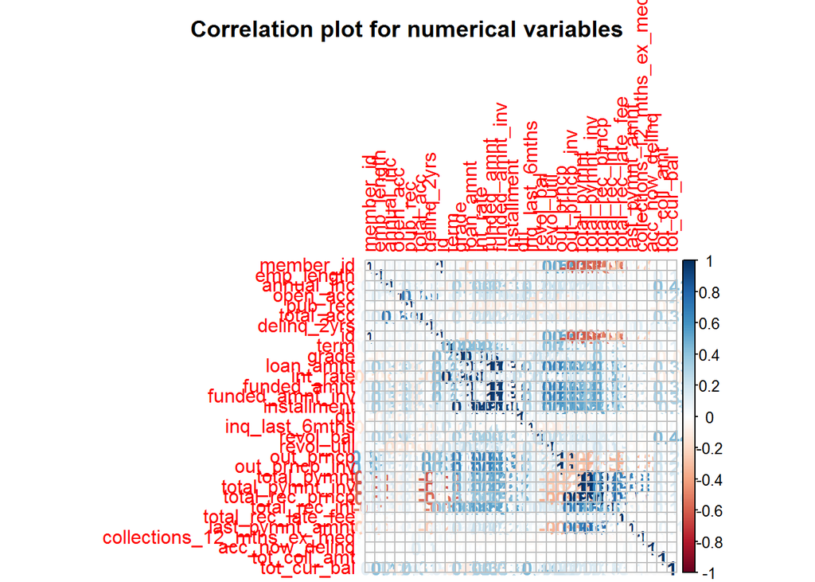

```r
numeric.var<-sapply(full_df, is.numeric)
corr.matrix<-cor(full_df[,numeric.var])
corrplot(corr.matrix, main="\n\nCorrelation plot for numerical variables", method="number", na.label = "NA")
```

### Let’s visualize some of the variables

Distribution of the grade

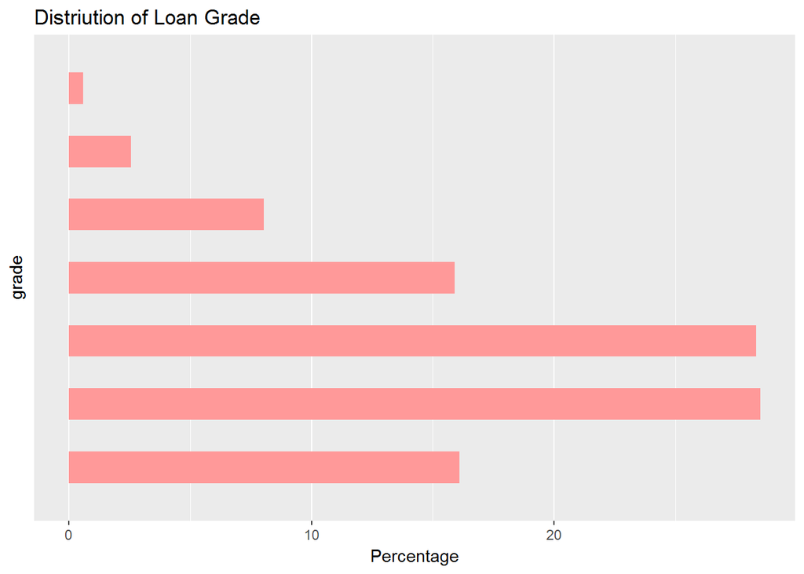

```r
g1<-ggplot(full_df, aes(x=grade)) + ggtitle("Distriution of Loan Grade") + xlab("Grade") + geom_bar(aes(y = 100*(..count..)/sum(..count..)), width = 0.5, fill="#FF9999") + ylab("Percentage") + coord_flip() +
  scale_x_discrete(name="grade")
g1
```

Relation between grade and loan status

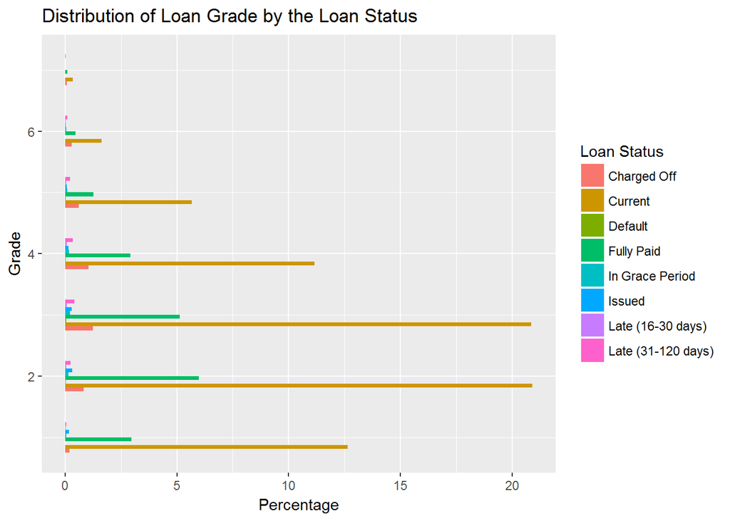

```r
g2<-ggplot(full_df, aes(x=grade, fill=as.factor(loan_status))) + ggtitle("Distribution of Loan Grade by the Loan Status") + xlab("Grade") + geom_bar(aes(y = 100*(..count..)/sum(..count..)), position = "dodge", width = 0.5) + ylab("Percentage") + coord_flip() +  scale_fill_discrete(name = "Loan Status")
g2
```

Distribution of variables

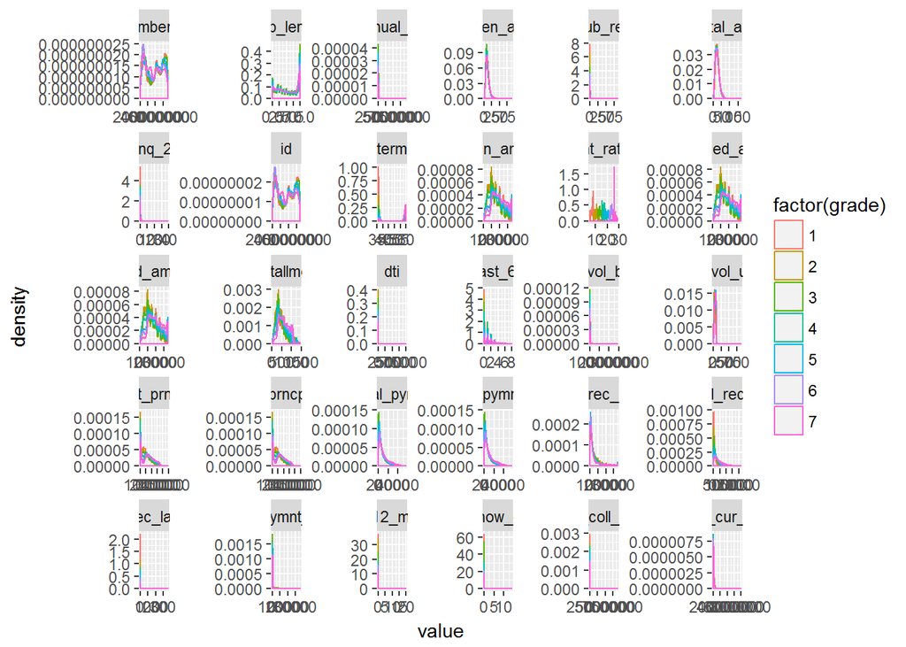

```r
numeric_cols<-sapply(full_df, is.numeric)
full_df.lngf<-melt(full_df[, numeric_cols], id.vars = "grade")
g3<-ggplot(aes(x=value, group=grade, colour=factor(grade)), data=full_df.lngf) + geom_density() + facet_wrap(~variable, scales = "free")
g3
```

View the numerical variables along boxplots

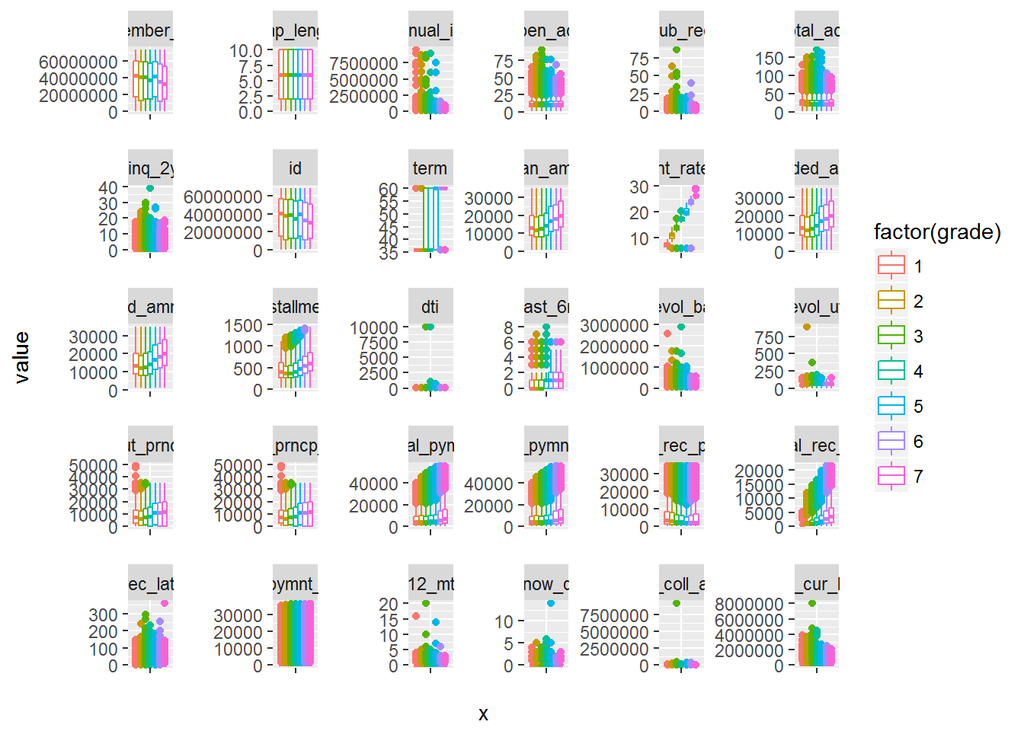

```r
# View plots are a good way of also showing outliers
g4<-ggplot(aes(x="", y=value, group=grade, colour=factor(grade)), data=full_df.lngf) + geom_boxplot() + facet_wrap(~variable, scales = "free")
g4
```

view trend of the loan amount over the issue date

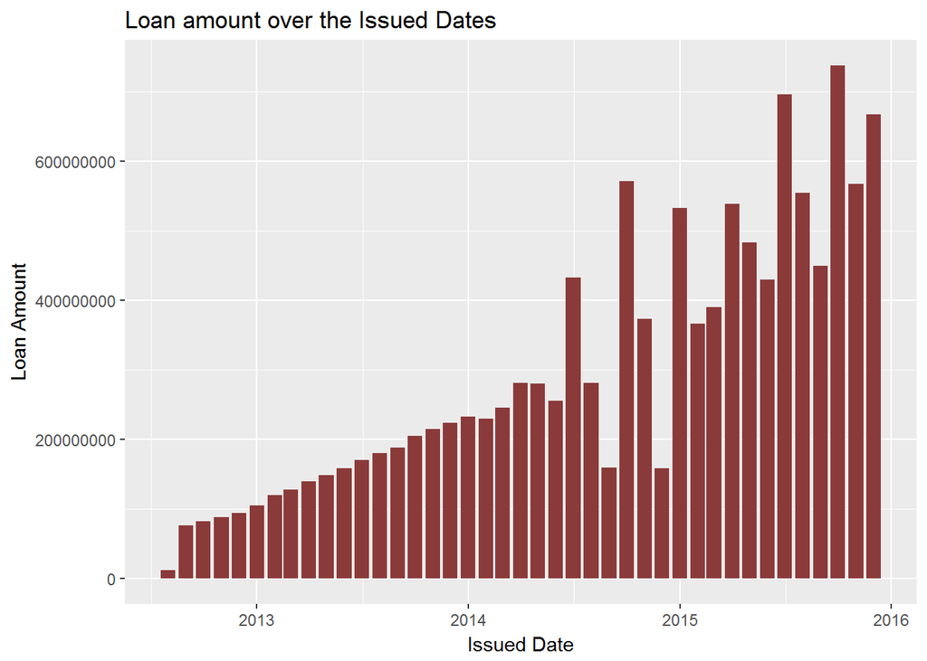

```r
full_df$issue_d<-dmy(paste0("01-", full_df$issue_d))
g5<-ggplot(full_df, aes(x=issue_d, y=loan_amnt)) + stat_summary(fun.y = "sum", geom = "bar", fill="indianred4") + xlab("Issued Date") + ylab("Loan Amount") + ggtitle("Loan amount over the Issued Dates")
g5
```

Visualize the states vs loan amount

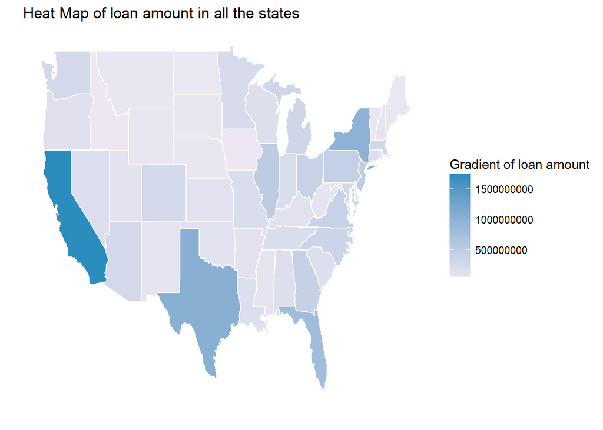

```r
library(maps)
full_df$region<-full_df$addr_state
full_df$region<-as.factor(full_df$region)
levels(full_df$region)<-c("alaska", "alabama","arkansas", "arizona", "california","colorado","connecticut","district of columbia","delaware","florida","georgia","hawaii","iowa","idaho","illinois","indiana","kansas","kentucky","louisiana","massachusetts","maryland","maine","michigan","minnesota","missouri","mississippi","montana","north carolina","north dakota","nebraska","new hampshire","new jersey","new mexico","nevada","new york","ohio","oklahoma","oregon","pennsylvania","rhode island","south carolina","south dakota","tennessee","texas","utah","virginia","washington","wisconsin","vermont", "west virginia","wyoming")

states<-map_data("state")

# create view by loan
state_by_loan<-full_df %>%
  group_by(region) %>%
  summarise(value = sum(loan_amnt, na.rm = TRUE))


state_by_loan$region<-as.character(state_by_loan$region)
state_by_loan<-as.data.frame(state_by_loan)
Total<-merge(states, state_by_loan, by = "region")

options(scipen=999)
g6<-ggplot() + geom_polygon(data = Total, aes(x=long, y=lat, group = group, fill=Total$value), colour = "white") + scale_fill_continuous(low = "#ece7f2", high = "#2b8cbe", guide = "colorbar") + theme_bw() + labs(fill = "Gradient of loan amount", title = "Heat Map of loan amount in all the states", x="", y="") + scale_y_continuous(breaks = c()) + scale_x_continuous(breaks = c()) + theme(panel.border = element_blank())
g6
```

If you want to save the resulting image to e.g., png then put it as follows:

```r
options(scipen=999)
png("state_loanamount_map.png", width=600, height=480)
ggplot() + geom_polygon(data = Total, aes(x=long, y=lat, group = group, fill=Total$value), colour = "white") + scale_fill_continuous(low = "#ece7f2", high = "#2b8cbe", guide = "colorbar") + theme_bw() + labs(fill = "Gradient of loan amount", title = "Heat Map of loan amount in all the states", x="", y="") + scale_y_continuous(breaks = c()) + scale_x_continuous(breaks = c()) + theme(panel.border = element_blank())
dev.off()
```

## Save the data for future use

```r
saveRDS(full_df, file="myLoanData.rds")
```

——-End of analysis——–